# Comparison and Integration of Annotation Sources

Carlota Myhre de Gouveia

2026-04-24

# Introduction

This report summarises, compares, and integrates the different annotation sources available for the *Symphodus melops* transcriptome, including EggNOG, InterProScan, Trinotate, and genome-based annotations.

# Analysis

## Load necessary packages

```r
suppressPackageStartupMessages({
  library(tidyverse)
  library(UpSetR)
  library(knitr)
  library(DT)
    library(here)
})
```

## Load and Inspect Annotation Sources

```r
## EggNOG annotation
# Read file as raw text
egg_raw <- readLines("results/annotation/eggnog/Trinity.emapper.annotations")
# Convert literal "\t" into real tabs
egg_raw <- gsub("\\\\t", "\t", egg_raw)
# Identify the header line (the one starting with "#query")
header_line <- egg_raw[grepl("^#query", egg_raw)]
# Extract column names from the header
col_names <- strsplit(sub("^#", "", header_line), "\t")[[1]]
# Extract all data lines (those NOT starting with "#")
data_lines <- egg_raw[!grepl("^#", egg_raw)]
# Read the data into a table using the extracted header
eggnog <- read.delim(
  textConnection(data_lines),
  header = FALSE,
  sep = "\t",
  quote = "",
  stringsAsFactors = FALSE
)
# Assign the correct column names
colnames(eggnog) <- col_names


## InterProScan output
ips <- read_tsv(
  "results/annotation/ips/IPS_merged.tsv",
  col_names = FALSE
)

## Trinotate full report
trinotate_report <- read_tsv(
  "results/annotation/trinotate/trinotate_final/trinotate_annotation_report.xls"
)

## SignalP predictions
signalp <- read_tsv(
  "results/annotation/trinotate/signalp/signalp_merged.output.gff3",
  col_names = FALSE,
  comment = "##",
  show_col_types = FALSE
)
## Assign the correct column names
colnames(signalp) <- c(
  "seqid", "source", "type", "start", "end",
  "score", "strand", "phase", "attributes"
)


# DeepTMHMM GFF3
tmhmm <- read_tsv(
  "results/annotation/trinotate/tmhmm/tmhmm_clean.gff3",
  col_names = FALSE,
  comment = "##",
  show_col_types = FALSE
)
# Assign column names
colnames(tmhmm) <- c(
  "seqid", "source", "type", "start", "end",
  "score", "strand", "phase", "attributes"
)

## Genome-based annotation
genome_based <- read_tsv(
  "results/annotation/genome_based/trinities_filteringby_cov_summary.tsv"
)

# ---- Row counts table ----
row_counts <- data.frame(
  Source = c("EggNOG", "IPS", "Trinotate", "SignalP", "TMHMM", "Genome-based"),
  Rows   = c(nrow(eggnog), nrow(ips), nrow(trinotate_report),
             nrow(signalp), nrow(tmhmm), nrow(genome_based))
)

kable(row_counts, caption = "Row counts per annotation source")
```

Row counts per annotation source

| Source | Rows |
| --- | --- |
| EggNOG | 206874 |
| IPS | 2220584 |
| Trinotate | 517436 |
| SignalP | 16722 |
| TMHMM | 111624 |
| Genome-based | 355748 |

```r
# ---- Compact previews as tables ----
kable(head(eggnog, 5), caption = "EggNOG preview (first 5 rows)")
```

EggNOG preview (first 5 rows)

| query | seed_ortholog | evalue | score | eggNOG_OGs | max_annot_lvl | COG_category | Description | Preferred_name | GOs | EC | KEGG_ko | KEGG_Pathway | KEGG_Module | KEGG_Reaction | KEGG_rclass | BRITE | KEGG_TC | CAZy | BiGG_Reaction | PFAMs |
| --- | --- | --- | --- | --- | --- | --- | --- | --- | --- | --- | --- | --- | --- | --- | --- | --- | --- | --- | --- | --- |
| TRINITY_GG_1000_c0_g1_i1.p1 | 8010.XP_010868907.1 | 0 | 127 | 2CMAB@1\|root,2QPSQ@2759\|Eukaryota,39XFZ@33154\|Opisthokonta,3BKCQ@33208\|Metazoa,3D5EX@33213\|Bilateria,48CR0@7711\|Chordata,499IK@7742\|Vertebrata,49XUG@7898\|Actinopterygii | 33208\|Metazoa | T | Odorant receptor, family E, subfamily 120, member 1 | - | - | - | ko:K04257 | ko04740,map04740 | - | - | - | ko00000,ko00001,ko04030 | - | - | - | - |
| TRINITY_GG_1002_c11_g1_i2.p1 | 215358.XP_010730531.1 | 0 | 842 | KOG3626@1\|root,KOG3626@2759\|Eukaryota,38DV9@33154\|Opisthokonta,3BCPB@33208\|Metazoa,3CSZS@33213\|Bilateria,489WX@7711\|Chordata,494EU@7742\|Vertebrata,49QSM@7898\|Actinopterygii | 33208\|Metazoa | Q | Solute carrier organic anion transporter family member | SLCO3A1 | GO:0003674,GO:0005215,GO:0005575,GO:0005623,GO:0005886,GO:0005887,GO:0006810,GO:0006811,GO:0006820,GO:0006857,GO:0006869,GO:0008150,GO:0008509,GO:0008514,GO:0009925,GO:0009986,GO:0010876,GO:0015075,GO… | - | ko:K14353,ko:K14356 | - | - | - | - | ko00000,ko02000 | 2.A.60.1 | - | - | OATP |
| TRINITY_GG_1002_c11_g1_i3.p1 | 215358.XP_010730531.1 | 0 | 755 | KOG3626@1\|root,KOG3626@2759\|Eukaryota,38DV9@33154\|Opisthokonta,3BCPB@33208\|Metazoa,3CSZS@33213\|Bilateria,489WX@7711\|Chordata,494EU@7742\|Vertebrata,49QSM@7898\|Actinopterygii | 33208\|Metazoa | Q | Solute carrier organic anion transporter family member | SLCO3A1 | GO:0003674,GO:0005215,GO:0005575,GO:0005623,GO:0005886,GO:0005887,GO:0006810,GO:0006811,GO:0006820,GO:0006857,GO:0006869,GO:0008150,GO:0008509,GO:0008514,GO:0009925,GO:0009986,GO:0010876,GO:0015075,GO… | - | ko:K14353,ko:K14356 | - | - | - | - | ko00000,ko02000 | 2.A.60.1 | - | - | OATP |
| TRINITY_GG_1002_c11_g1_i4.p1 | 144197.XP_008296061.1 | 0 | 640 | KOG3626@1\|root,KOG3626@2759\|Eukaryota,38DV9@33154\|Opisthokonta,3BCPB@33208\|Metazoa,3CSZS@33213\|Bilateria,489WX@7711\|Chordata,494EU@7742\|Vertebrata,49QSM@7898\|Actinopterygii | 33208\|Metazoa | Q | Solute carrier organic anion transporter family member | SLCO3A1 | GO:0003674,GO:0005215,GO:0005575,GO:0005623,GO:0005886,GO:0005887,GO:0006810,GO:0006811,GO:0006820,GO:0006857,GO:0006869,GO:0008150,GO:0008509,GO:0008514,GO:0009925,GO:0009986,GO:0010876,GO:0015075,GO… | - | ko:K14353,ko:K14356 | - | - | - | - | ko00000,ko02000 | 2.A.60.1 | - | - | OATP |
| TRINITY_GG_1002_c2_g2_i2.p1 | 7955.ENSDARP00000099766 | 0 | 244 | KOG1075@1\|root,KOG1075@2759\|Eukaryota,39N4Q@33154\|Opisthokonta,3B9WN@33208\|Metazoa,3D1S8@33213\|Bilateria,48C1W@7711\|Chordata,49N8J@7742\|Vertebrata,4A94B@7898\|Actinopterygii | 33208\|Metazoa | S | Reverse transcriptase (RNA-dependent DNA polymerase) | - | - | - | - | - | - | - | - | - | - | - | - | RVT_1 |

```r
kable(head(ips, 5), caption = "InterProScan preview (first 5 rows)")
```

InterProScan preview (first 5 rows)

| X1 | X2 | X3 | X4 | X5 | X6 | X7 | X8 | X9 | X10 | X11 | X12 | X13 | X14 |
| --- | --- | --- | --- | --- | --- | --- | --- | --- | --- | --- | --- | --- | --- |
| TRINITY_GG_1000_c0_g1_i1.p1 | 33dba4c86c520cfb96c83ec1c1530729 | 129 | Gene3D | G3DSA:1.10.443.10 | Intergrase catalytic core | 1 | 111 | 2.9E-12 | TRUE | 18-01-2026 | IPR013762 | Integrase-like, catalytic domain superfamily | GO:0003677\|GO:0006310\|GO:0015074 |
| TRINITY_GG_1000_c0_g1_i1.p1 | 33dba4c86c520cfb96c83ec1c1530729 | 129 | PANTHER | PTHR33066 | INTEGRASE_SAM-LIKE_N DOMAIN-CONTAINING PROTEIN | 2 | 116 | 4.6E-24 | TRUE | 18-01-2026 | - | - | NA |
| TRINITY_GG_1000_c0_g1_i1.p1 | 33dba4c86c520cfb96c83ec1c1530729 | 129 | SUPERFAMILY | SSF56349 | DNA breaking-rejoining enzymes | 6 | 112 | 5.1E-13 | TRUE | 18-01-2026 | IPR011010 | DNA breaking-rejoining enzyme, catalytic core | GO:0003677 |
| TRINITY_GG_1002_c11_g1_i2.p1 | bbc499ba4d84379d759346c15d24b26e | 435 | Gene3D | G3DSA:1.20.1250.20 | MFS general substrate transporter like domains | 34 | 435 | 3.8E-23 | TRUE | 18-01-2026 | IPR036259 | MFS transporter superfamily | - |
| TRINITY_GG_1002_c11_g1_i2.p1 | bbc499ba4d84379d759346c15d24b26e | 435 | NCBIfam | TIGR00805 | OAT family organic anion transporter | 22 | 434 | 5.8E-107 | TRUE | 18-01-2026 | IPR004156 | Organic anion transporter polypeptide | GO:0016020\|GO:0055085 |

```r
kable(head(trinotate_report, 5), caption = "Trinotate preview (first 5 rows)")
```

Trinotate preview (first 5 rows)

| #gene_id | transcript_id | sprot_Top_BLASTX_hit | infernal | prot_id | prot_coords | sprot_Top_BLASTP_hit | Pfam | SignalP | TmHMM | eggnog | Kegg | gene_ontology_BLASTX | gene_ontology_BLASTP | gene_ontology_Pfam | transcript | peptide |
| --- | --- | --- | --- | --- | --- | --- | --- | --- | --- | --- | --- | --- | --- | --- | --- | --- |
| TRINITY_GG_1_c1_g1 | TRINITY_GG_1_c1_g1_i1 | . | . | . | . | . | . | . | . | . | . | . | . | . | . | . |
| TRINITY_GG_2_c0_g1 | TRINITY_GG_2_c0_g1_i1 | sp\|Q8IWY8\|ZSC29_HUMAN<sup>sp\|Q8IWY8\|ZSC29_HUMAN</sup>Q:432-704,H:409-494<sup>34.066%ID</sup>E:8.47e-09<sup>.</sup>.`sp&#124;Q8IWY8&#124;ZSC29_HUMAN^sp&#124;Q8IWY8&#124;ZSC29_HUMAN^Q:432-704,H:246-… | PF13837.13<sup>Myb_DNA-bind_4</sup>NULL<sup>25-113</sup>E:2e-19 | sigP:0 | . | . | . | . | . | . | . | . |  |  |  |  |
| TRINITY_GG_2_c0_g1 | TRINITY_GG_2_c0_g1_i10 | . | . | . | . | . | . | . | . | . | . | . | . | . | . | . |
| TRINITY_GG_2_c0_g1 | TRINITY_GG_2_c0_g1_i11 | . | . | . | . | . | . | . | . | . | . | . | . | . | . | . |
| TRINITY_GG_2_c0_g1 | TRINITY_GG_2_c0_g1_i12 | . | . | TRINITY_GG_2_c0_g1_i12.p1 | 360-680[+] | . | . | sigP:0 | . | . | . | . | . | . | . | . |

```r
kable(head(signalp, 5), caption = "SignalP preview (first 5 rows)")
```

SignalP preview (first 5 rows)

| seqid | source | type | start | end | score | strand | phase | attributes |
| --- | --- | --- | --- | --- | --- | --- | --- | --- |
| TRINITY_GG_1002_c3_g1_i1.p1 TRINITY_GG_1002_c3_g1TRINITY_GG_1002_c3_g1_i1.p1 ORF type:complete len:286 (+),score=91.06,sp\|Q64387\|PNOC_MOUSE\|31.455\|2.37e-12,sp\|Q13519\|PNOC_HUMAN\|30.189\|8.62e-12… | SignalP-6.0 | signal_peptide | 1 | 18 | 0.9997670 | . | . | . |
| TRINITY_GG_1002_c3_g1_i2.p1 TRINITY_GG_1002_c3_g1TRINITY_GG_1002_c3_g1_i2.p1 ORF type:complete len:286 (+),score=91.06,sp\|Q64387\|PNOC_MOUSE\|31.455\|2.37e-12,sp\|Q13519\|PNOC_HUMAN\|30.189\|8.62e-12… | SignalP-6.0 | signal_peptide | 1 | 18 | 0.9997670 | . | . | . |
| TRINITY_GG_1002_c3_g1_i3.p1 TRINITY_GG_1002_c3_g1TRINITY_GG_1002_c3_g1_i3.p1 ORF type:complete len:286 (+),score=91.06,sp\|Q64387\|PNOC_MOUSE\|31.455\|2.37e-12,sp\|Q13519\|PNOC_HUMAN\|30.189\|8.62e-12… | SignalP-6.0 | signal_peptide | 1 | 18 | 0.9997670 | . | . | . |
| TRINITY_GG_1002_c3_g1_i4.p1 TRINITY_GG_1002_c3_g1TRINITY_GG_1002_c3_g1_i4.p1 ORF type:complete len:286 (+),score=91.06,sp\|Q64387\|PNOC_MOUSE\|31.455\|2.37e-12,sp\|Q13519\|PNOC_HUMAN\|30.189\|8.62e-12… | SignalP-6.0 | signal_peptide | 1 | 18 | 0.9997670 | . | . | . |
| TRINITY_GG_1002_c9_g2_i1.p1 TRINITY_GG_1002_c9_g2TRINITY_GG_1002_c9_g2_i1.p1 ORF type:complete len:265 (-),score=137.39,sp\|P31581\|HCE2_ORYLA\|63.118\|6.05e-122,sp\|P31580\|HCE1_ORYLA\|65.918\|1.32e-… | SignalP-6.0 | signal_peptide | 1 | 18 | 0.9997414 | . | . | . |

```r
kable(head(tmhmm, 5), caption = "TMHMM preview (first 5 rows)")
```

TMHMM preview (first 5 rows)

| seqid | source | type | start | end | score | strand | phase | attributes |
| --- | --- | --- | --- | --- | --- | --- | --- | --- |
| TRINITY_GG_595_c61_g2_i22.p1 | DeepTMHMM | TMhelix | 3 | 22 | . | . | . | ID=TRINITY_GG_595_c61_g2_i22.p1_TMhelix_3_22 |
| TRINITY_GG_595_c61_g2_i22.p1 | DeepTMHMM | TMhelix | 35 | 55 | . | . | . | ID=TRINITY_GG_595_c61_g2_i22.p1_TMhelix_35_55 |
| TRINITY_GG_595_c61_g2_i22.p1 | DeepTMHMM | TMhelix | 84 | 94 | . | . | . | ID=TRINITY_GG_595_c61_g2_i22.p1_TMhelix_84_94 |
| TRINITY_GG_595_c61_g2_i22.p1 | DeepTMHMM | TMhelix | 96 | 107 | . | . | . | ID=TRINITY_GG_595_c61_g2_i22.p1_TMhelix_96_107 |
| TRINITY_GG_595_c61_g2_i22.p1 | DeepTMHMM | TMhelix | 137 | 157 | . | . | . | ID=TRINITY_GG_595_c61_g2_i22.p1_TMhelix_137_157 |

```r
kable(head(genome_based, 5), caption = "Genome-based annotation preview (first 5 rows)")
```

Genome-based annotation preview (first 5 rows)

| Trinity_ID | GFF_Transcript | Gene_ID | Coverage_% | GO_Terms | Dbxref | UniProt_ID |
| --- | --- | --- | --- | --- | --- | --- |
| TRINITY_GG_995_c550_g10_i1 | FUNCM00000021382 | FUNCG00000021382 | 100.0000 | NA | MobiDBLite:mobidb-lite,PANTHER:PTHR14195 | Q6PE65 |
| TRINITY_GG_880_c449_g1_i1 | FUNCM00000011179 | FUNCG00000011179 | 100.0000 | NA | Coils:Coil,Gene3D:G3DSA:2.30.29.30,Gene3D:G3DSA:3.80.10.10,InterPro:IPR031943,InterPro:IPR011993,InterPro:IPR041245,InterPro:IPR032675,MobiDBLite:mobidb-lite,PANTHER:PTHR24112,Pfam:PF16000,Pfam:PF1788… | Q5XHY1 |
| TRINITY_GG_1349_c30_g2_i1 | FUNCM00000022083 | FUNCG00000022083 | 100.0000 | NA | NA | NA |
| TRINITY_GG_1334_c108_g1_i3 | FUNCM00000003182 | FUNCG00000003182 | 79.3449 | GO:0003755,GO:0005515 | FunFam:G3DSA:1.25.40.10:FF:000052,Gene3D:G3DSA:3.10.50.40,Gene3D:G3DSA:1.25.40.10,InterPro:IPR046357,InterPro:IPR011990,InterPro:IPR001179,InterPro:IPR039663,MobiDBLite:mobidb-lite,PANTHER:PTHR11242,P… | O08915 |
| TRINITY_GG_1562_c1537_g4_i1 | FUNCM00000020598 | FUNCG00000020598 | 100.0000 | GO:0005737 | InterPro:IPR007531,MobiDBLite:mobidb-lite,PANTHER:PTHR16294,Pfam:PF04440 | Q5ZKM0 |

## Standardize Trinity IDs across annotation sources

```r
# Helper: extract gene-level ID from any Trinity-style ID
extract_gene_id <- function(x) {
  x %>%
    str_remove("\\.p\\d+$") %>%   # remove .p1, .p2, etc.
    str_remove("_i\\d+$") %>%     # remove isoform _i1, _i2, etc.
    str_replace("^#", "")         # remove leading # if present
}

# ---- EggNOG ----
# first column is protein ID like TRINITY_GG_1000_c0_g1_i1.p1
eggnog <- eggnog %>%
  rename(protein_id = query) %>%
  mutate(
    transcript_id = str_remove(protein_id, "\\.p\\d+$"),
    gene_id       = extract_gene_id(transcript_id)
  )

# ---- IPS ----
ips <- ips %>%
  rename(protein_id = X1) %>%
  mutate(
    transcript_id = str_remove(protein_id, "\\.p\\d+$"),
    gene_id       = extract_gene_id(transcript_id)
  )

# ---- Trinotate ----
trinotate_report <- trinotate_report %>%
  rename(gene_id = `#gene_id`) %>%
  mutate(
    gene_id       = extract_gene_id(gene_id),
    transcript_id = transcript_id
  )

# ---- SignalP ----
signalp <- signalp %>%
  mutate(
    # Extract the transcript ID from the seqid field
    transcript_id = sub("\\.p[0-9]+.*$", "", seqid),

    # Derive gene_id (not used for merging)
    gene_id = sub("_i.*", "", transcript_id)
  )

# ---- TMHMM ----
tmhmm <- tmhmm %>%
  mutate(
    transcript_id = sub("\\.p[0-9]+$", "", seqid)
  )



# ---- Genome-based ----
genome_based <- genome_based %>%
  rename(transcript_id = Trinity_ID) %>%
  mutate(
    gene_id = extract_gene_id(transcript_id)
  )
```

## Integrate SignalP-6.0 into Trinotate report

```r
# Identify transcripts with a signal peptide
signalp_hits <- signalp %>%
  filter(type == "signal_peptide") %>%
  distinct(transcript_id) %>%
  mutate(SignalP = "YES")

# Remove old Trinotate SignalP column
trinotate_report <- trinotate_report %>% select(-SignalP)

# Build full transcript list from Trinotate
all_transcripts <- trinotate_report %>%
  select(transcript_id) %>%
  distinct()

# Create complete YES/NO table (join ONLY on transcript_id)
signalp_full <- all_transcripts %>%
  left_join(signalp_hits, by = "transcript_id") %>%
  mutate(SignalP = ifelse(is.na(SignalP), "NO", SignalP))

# Merge into Trinotate report
trinotate_report <- trinotate_report %>%
  left_join(signalp_full, by = "transcript_id")
```

## Integrate DeepTmhmm into Trinotate report

```r
# ---- Identify transcripts with ≥1 TM helix ----
tmhmm_hits <- tmhmm %>%
  filter(type == "TMhelix") %>%
  distinct(transcript_id) %>%
  mutate(TMHMM = "YES")

# ---- Build full transcript list ----
all_transcripts <- trinotate_report %>%
  select(transcript_id) %>%
  distinct()

tmhmm_full <- all_transcripts %>%
  left_join(tmhmm_hits, by = "transcript_id") %>%
  mutate(TMHMM = ifelse(is.na(TMHMM), "NO", TMHMM))

# ---- Merge TMHMM into Trinotate report ----
trinotate_report <- trinotate_report %>%
  { if ("TMHMM" %in% colnames(.)) select(., -TMHMM) else . } %>%
  left_join(tmhmm_full, by = "transcript_id")
```

## Extraction of relevant annotation fields from each source

### EggNog extraction function

```r
extract_eggnog_annotations <- function(gene_list, eggnog) {

  clean_field <- function(x) {
    x <- unique(na.omit(x))
    x <- x[x != "-" & x != ""]
    if (length(x) == 0) return(NA)
    x <- gsub(",", ";", x)   # normalize EggNOG comma lists
    paste(x, collapse = ";")
  }

  eggnog %>%
    filter(gene_id %in% gene_list) %>%
    mutate(GO_list = strsplit(GOs, ",")) %>%
    unnest(GO_list) %>%
    filter(!GO_list %in% c("GO:0003674","GO:0005575","GO:0008150")) %>% # drop roots
    group_by(gene_id) %>%
    summarise(
      egg_ortholog = clean_field(seed_ortholog),
      egg_desc     = clean_field(Description),
      egg_COG      = clean_field(COG_category),
      egg_KO       = clean_field(KEGG_ko),
      egg_KEGGmap  = clean_field(KEGG_Pathway),
      egg_PFAM     = clean_field(PFAMs),
      egg_GO       = paste(unique(GO_list), collapse=";"),  # deduplicate
      .groups = "drop"
    )
}
```

### IPS extraction function

```r
extract_ips_annotations <- function(gene_list, ips) {

  clean_field <- function(x) {
    x <- gsub("[|,]", ";", x)      # normalize | and , to ;
    x <- gsub("^;|;$", "", x)      # trim leading/trailing ;
    x <- gsub(";;+", ";", x)       # collapse multiple ;;
    x[x == ""] <- NA               # empty -> NA
    x
  }

  ips %>%
    filter(gene_id %in% gene_list) %>%
    group_by(gene_id) %>%
    summarise(
      ips_IPR  = clean_field(
        paste0(na.omit(unique(X12[X12 != "-"])), collapse = ";")
      ),
      ips_PFAM = clean_field(
        paste0(na.omit(unique(X5[X5 != "-"])), collapse = ";")
      ),
      ips_GO   = clean_field(
        paste0(na.omit(unique(X14[X14 != "-"])), collapse = ";")
      ),
      .groups = "drop"
    )
}
```

### Trinotate Extraction Function

```r
extract_trinotate_annotations <- function(gene_list, trinotate_report) {

  clean_field <- function(x) {
    x <- gsub("^;|;$", "", x)
    x <- gsub(";;+", ";", x)
    x[x == ""] <- NA
    x
  }

  trinotate_report %>%
    filter(gene_id %in% gene_list) %>%
    group_by(gene_id) %>%
    summarise(
      trinotate_BLASTX = clean_field(
        paste0(
          na.omit(unique(sprot_Top_BLASTX_hit[sprot_Top_BLASTX_hit != "."])),
          collapse = ";"
        )
      ),

      trinotate_BLASTP = clean_field(
        paste0(
          na.omit(unique(sprot_Top_BLASTP_hit[sprot_Top_BLASTP_hit != "."])),
          collapse = ";"
        )
      ),

      trinotate_PFAM = clean_field(
        paste0(
          na.omit(unique(Pfam[Pfam != "."])),
          collapse = ";"
        )
      ),

      trinotate_GO = clean_field(
        paste0(
          na.omit(unique(c(
            gene_ontology_BLASTX[gene_ontology_BLASTX != "."],
            gene_ontology_BLASTP[gene_ontology_BLASTP != "."],
            gene_ontology_Pfam[gene_ontology_Pfam != "."]
          ))),
          collapse = ";"
        )
      ),

      trinotate_SignalP = ifelse(any(SignalP == "YES"), "YES", "NO"),
      trinotate_TMHMM   = ifelse(any(TMHMM == "YES"), "YES", "NO"),

      .groups = "drop"
    )
}
```

### Genome based annotation extraction function

```r
extract_genome_annotations <- function(gene_list, genome_based) {

  genome_based %>%
    filter(gene_id %in% gene_list) %>%
    # keep only the transcript with highest coverage
    group_by(gene_id) %>%
    slice_max(`Coverage_%`, n = 1, with_ties = FALSE) %>%
    ungroup() %>%
    transmute(
      gene_id,
      genome_best_transcript = transcript_id,
      genome_gene_id    = Gene_ID,
      genome_coverage   = `Coverage_%`,
      genome_GO         = ifelse(GO_Terms == "" | GO_Terms == "NA", NA, GO_Terms),
      genome_UniProt    = ifelse(UniProt_ID == "" | UniProt_ID == "NA", NA, UniProt_ID),
      genome_Dbxref     = ifelse(Dbxref == "" | Dbxref == "NA", NA, Dbxref)
    )
}
```

## Function to integrate all annotation sources in one single table for a set of genes

```r
integrate_annotations <- function(gene_list,
                                  eggnog,
                                  ips,
                                  trinotate_report,
                                  genome_based) {

  # Run each extraction function
  eggnog_ann   <- extract_eggnog_annotations(gene_list, eggnog)
  ips_ann      <- extract_ips_annotations(gene_list, ips)
  trinotate_ann <- extract_trinotate_annotations(gene_list, trinotate_report)
  genome_ann   <- extract_genome_annotations(gene_list, genome_based)

  # Sequentially join everything by gene_id
  integrated <- gene_list %>%
    tibble(gene_id = .) %>%
    left_join(eggnog_ann,   by = "gene_id") %>%
    left_join(ips_ann,      by = "gene_id") %>%
    left_join(trinotate_ann,by = "gene_id") %>%
    left_join(genome_ann,   by = "gene_id")

  return(integrated)
}
```

## Create master table

```r
# Use Trinotate IDs as master list
all_gene_ids <- unique(trinotate_report$gene_id)

# Integrate once
integrated_table <- integrate_annotations(
  all_gene_ids,
  eggnog,
  ips,
  trinotate_report,
  genome_based
)


# ---- Dimensions summary ----
summary_info <- data.frame(
  Genes = nrow(integrated_table),
  Annotation_fields = ncol(integrated_table)
)

kable(summary_info,
      caption = "Integrated table dimensions (rows = genes, columns = annotation fields)")
```

Integrated table dimensions (rows = genes, columns = annotation fields)

| Genes | Annotation_fields |
| --- | --- |
| 257710 | 23 |

```r
# ---- Preview of integrated table ----
kable(
  head(integrated_table, 10),
  caption = "Integrated annotation table (first 10 genes)"
)
```

Integrated annotation table (first 10 genes)

| gene_id | egg_ortholog | egg_desc | egg_COG | egg_KO | egg_KEGGmap | egg_PFAM | egg_GO | ips_IPR | ips_PFAM | ips_GO | trinotate_BLASTX | trinotate_BLASTP | trinotate_PFAM | trinotate_GO | trinotate_SignalP | trinotate_TMHMM | genome_best_transcript | genome_gene_id | genome_coverage | genome_GO | genome_UniProt | genome_Dbxref |
| --- | --- | --- | --- | --- | --- | --- | --- | --- | --- | --- | --- | --- | --- | --- | --- | --- | --- | --- | --- | --- | --- | --- |
| TRINITY_GG_1_c1_g1 | NA | NA | NA | NA | NA | NA | NA | NA | NA | NA | NA | NA | NA | NA | NO | NO | NA | NA | NA | NA | NA | NA |
| TRINITY_GG_2_c0_g1 | 215358.XP_010742906.1;144197.XP_008289549.1 | Myb/SANT-like DNA-binding domain | K | NA | NA | Myb_DNA-bind_4 | - | IPR026095;IPR044822 | G3DSA:1.10.10.60:FF:000032;G3DSA:1.10.10.60;mobidb-lite;PTHR22666;PF13837 | NA | sp\|Q8IWY8\|ZSC29_HUMAN<sup>sp\|Q8IWY8\|ZSC29_HUMAN</sup>Q:432-704,H:409-494<sup>34.066%ID</sup>E:8.47e-09<sup>.</sup>.`sp&#124;Q8IWY8&#124;ZSC29_HUMAN^sp&#124;Q8IWY8&#124;ZSC29_HUMAN^Q:432-704,H:246-… | PF13837.13<sup>Myb_DNA-bind_4</sup>NULL<sup>25-113</sup>E:2e-19;PF13837.13<sup>Myb_DNA-bind_4</sup>NULL<sup>22-110</sup>E:1.9e-19;PF13837.13<sup>Myb_DNA-bind_4</sup>NULL<sup>22-110</sup>E:1.1e-19 | NA | NO | NO | NA | NA | NA | NA | NA | NA |  |
| TRINITY_GG_2_c0_g3 | NA | NA | NA | NA | NA | NA | NA | NA | NA | NA | NA | NA | NA | NA | NO | NO | NA | NA | NA | NA | NA | NA |
| TRINITY_GG_2_c0_g2 | NA | NA | NA | NA | NA | NA | NA | NA | NA | NA | NA | NA | NA | NA | NO | NO | NA | NA | NA | NA | NA | NA |
| TRINITY_GG_2_c1_g1 | NA | NA | NA | NA | NA | NA | NA | NA | NA | NA | NA | NA | NA | NA | NO | NO | NA | NA | NA | NA | NA | NA |
| TRINITY_GG_2_c2_g1 | NA | NA | NA | NA | NA | NA | NA | NA | NA | NA | NA | NA | NA | NA | NO | NO | NA | NA | NA | NA | NA | NA |
| TRINITY_GG_2_c3_g1 | NA | NA | NA | NA | NA | NA | NA | NA | NA | NA | NA | NA | NA | NA | NO | NO | NA | NA | NA | NA | NA | NA |
| TRINITY_GG_2_c4_g1 | NA | NA | NA | NA | NA | NA | NA | NA | Coil;mobidb-lite | NA | NA | NA | NA | NA | NO | NO | TRINITY_GG_2_c4_g1_i6 | FUNCG00000000172 | 46.0396 | NA | NA | Coils:Coil,MobiDBLite:mobidb-lite |
| TRINITY_GG_2_c9_g1 | NA | NA | NA | NA | NA | NA | NA | NA | NA | NA | NA | NA | NA | NA | NO | NO | NA | NA | NA | NA | NA | NA |
| TRINITY_GG_2_c10_g1 | NA | NA | NA | NA | NA | NA | NA | NA | NA | NA | NA | NA | NA | NA | NO | NO | NA | NA | NA | NA | NA | NA |

## Annotation classification function

```r
# Function to check BLAST hit quality across multiple hits in a string
check_blast_hit <- function(hit_string, min_identity = 30, max_evalue = 1e-5) {
  if (is.na(hit_string)) return(FALSE)

  # Split into individual hits (semicolon-delimited)
  hits <- unlist(strsplit(hit_string, ";"))

  for (h in hits) {
    perc_identity <- stringr::str_extract(h, "\\d+\\.?\\d*%ID")
    evalue <- stringr::str_extract(h, "E:[^\\^]+")

    perc_identity <- as.numeric(stringr::str_remove(perc_identity, "%ID"))
    evalue <- as.numeric(stringr::str_remove(evalue, "E:"))

    good_identity <- !is.na(perc_identity) && perc_identity >= min_identity
    good_evalue   <- !is.na(evalue) && evalue <= max_evalue
    not_hypo      <- !grepl("hypothetical|uncharacterized", h, ignore.case = TRUE)

    if (good_identity && good_evalue && not_hypo) {
      return(TRUE)
    }
  }
  return(FALSE)
}

# Main classification function
classify_annotations <- function(integrated_table) {

  coverage_threshold_strong <- 70
  coverage_threshold_moderate <- 40

  integrated_table %>%
    dplyr::mutate(
      # Transcriptome strong evidence
      has_eggnog = if_any(c("egg_ortholog","egg_desc","egg_COG","egg_KO","egg_KEGGmap","egg_GO"),
                          ~ !is.na(.) & . != ""),
      has_ips_go = !is.na(ips_GO) & ips_GO != "",
      has_trinotate_go = !is.na(trinotate_GO) & trinotate_GO != "",
      blastx_strong = sapply(trinotate_BLASTX, check_blast_hit),
      blastp_strong = sapply(trinotate_BLASTP, check_blast_hit),
      has_blast = blastx_strong | blastp_strong,

      n_transcriptome_strong = (has_eggnog + has_ips_go + has_trinotate_go + has_blast),

      # Genome evidence
      has_genome_go      = !is.na(genome_GO) & genome_GO != "",
      has_genome_uniprot = !is.na(genome_UniProt) & genome_UniProt != "",
      has_genome_dbxref  = !is.na(genome_Dbxref) & genome_Dbxref != "",

      genome_strong      = (has_genome_go | has_genome_uniprot) & genome_coverage >= coverage_threshold_strong,
      genome_conditional = (has_genome_go | has_genome_uniprot) & genome_coverage >= coverage_threshold_moderate & genome_coverage < coverage_threshold_strong,
      genome_weak        = (has_genome_go | has_genome_uniprot) & genome_coverage < coverage_threshold_moderate,

      # Weak evidence (coalesced to avoid NA)
      has_signalp = trinotate_SignalP == "YES",
      has_tmhmm   = trinotate_TMHMM == "YES",
      has_pfam_ipr = if_any(c("egg_PFAM","ips_IPR","ips_PFAM","trinotate_PFAM"), ~ !is.na(.) & . != ""),

      weak_sources = dplyr::coalesce(
        (has_signalp | has_tmhmm | has_pfam_ipr | has_genome_dbxref | genome_weak),
        FALSE
      ),

      # Total strong sources depending on coverage
      strong_sources = dplyr::case_when(
        genome_coverage >= coverage_threshold_strong ~ n_transcriptome_strong + genome_strong,
        genome_coverage >= coverage_threshold_moderate & genome_coverage < coverage_threshold_strong ~ n_transcriptome_strong + genome_conditional,
        genome_coverage < coverage_threshold_moderate ~ n_transcriptome_strong,
        genome_coverage == 0 ~ n_transcriptome_strong
      ),

      # Classification based on full case matrix
      annotation_class = dplyr::case_when(
        # High coverage
        genome_coverage >= coverage_threshold_strong & strong_sources >= 2 ~ "Well-annotated",
        genome_coverage >= coverage_threshold_strong & strong_sources == 1 ~ "Partially annotated",
        genome_coverage >= coverage_threshold_strong & strong_sources == 0 & weak_sources ~ "Weakly annotated",
        genome_coverage >= coverage_threshold_strong & strong_sources == 0 & !weak_sources ~ "Mapped only",

        # Moderate coverage
        genome_coverage >= coverage_threshold_moderate & genome_coverage < coverage_threshold_strong & n_transcriptome_strong >= 2 ~ "Well-annotated",
        genome_coverage >= coverage_threshold_moderate & genome_coverage < coverage_threshold_strong & (n_transcriptome_strong == 1 | genome_conditional) ~ "Partially annotated",
        genome_coverage >= coverage_threshold_moderate & genome_coverage < coverage_threshold_strong & n_transcriptome_strong == 0 & !genome_conditional & weak_sources ~ "Weakly annotated",
        genome_coverage >= coverage_threshold_moderate & genome_coverage < coverage_threshold_strong & n_transcriptome_strong == 0 & !genome_conditional & !weak_sources ~ "Mapped only",

        # Low coverage
        genome_coverage > 0 & genome_coverage < coverage_threshold_moderate & n_transcriptome_strong >= 2 ~ "Well-annotated",
        genome_coverage > 0 & genome_coverage < coverage_threshold_moderate & n_transcriptome_strong == 1 ~ "Partially annotated",
        genome_coverage > 0 & genome_coverage < coverage_threshold_moderate & n_transcriptome_strong == 0 & weak_sources ~ "Weakly annotated",
        genome_coverage > 0 & genome_coverage < coverage_threshold_moderate & n_transcriptome_strong == 0 & !weak_sources ~ "Mapped only",

        # No coverage
        genome_coverage == 0 & n_transcriptome_strong >= 2 ~ "Well-annotated",
        genome_coverage == 0 & n_transcriptome_strong == 1 ~ "Partially annotated",
        genome_coverage == 0 & n_transcriptome_strong == 0 & weak_sources ~ "Weakly annotated",
        genome_coverage == 0 & n_transcriptome_strong == 0 & !weak_sources ~ "Unannotated",

        # Catch-all safety net
        TRUE ~ "Unannotated"
      )
    )
}
```

## Classify and summarise all annotations

```r
# Classify
classified_genes <- classify_annotations(integrated_table)

# Summaries
classified_genes %>%
  count(annotation_class) %>%
  mutate(percent = round(n / sum(n) * 100, 1))
```

```
## # A tibble: 5 × 3
##   annotation_class         n percent
##   <chr>                <int>   <dbl>
## 1 Mapped only           2051     0.8
## 2 Partially annotated 146597    56.9
## 3 Unannotated          63152    24.5
## 4 Weakly annotated      8986     3.5
## 5 Well-annotated       36924    14.3
```

```r
## Save integrated and classified table
write_csv(classified_genes,
          file = "results/annotation/annotations.csv")
```

## Genome-based Annotation Summary

### Genome annotation overview and transcriptome–genome overlap

### Transcriptome–genome intersection statistics

### Genome annotation (GFF)

- **Total genes:** 24911
- **Curated (UniProt):** 19172 (77%)
- **Annotated (GO/InterPro/Pfam/etc.):** 22904 (92%)
- **Unannotated:** 2007 (8%)

Genome–transcriptome coverage categories and annotation status

| Coverage class | Total genes | Curated | Annotated | Unannotated |
| --- | --- | --- | --- | --- |
| 40–70% | 1609 | 993 | 1366 | 243 |
| <40% | 1646 | 678 | 1104 | 542 |
| ≥70% | 19786 | 16970 | 19279 | 507 |
| Total | 23041 | 18641 | 21749 | 1292 |

### Transcriptome–genome intersection summary

- **Transcriptome–genome intersection total genes:** 23041
- **Low coverage (<40%):** 1646 genes (7%)
- **Moderate coverage (40–70%):** 1609 genes (7%)
- **High coverage (≥70%):** 19786 genes (86%)
- **Curated (UniProt):** 18641 (81%)
- **Annotated (GO/InterPro/Pfam/etc.):** 21749 (94%)
- **Unannotated:** 1292 (6%)
- **Moderate to high coverage (≥40%):** **21395** genes  
  (93%), of which  
  **17963** are curated (84%),  
  **20645** are annotated (96%), and  
  **750** remain unannotated (3.5%).

Of the **19172 curated genes annotated in the genome**, **18641 (97%)** were retained in the transcriptome–genome intersection, while **531 (3%)** curated genes were absent. These missing curated genes likely represent loci not expressed in the sampled transcriptome or annotation artifacts from genome gene models. Thus, while the intersection enriches for annotations, it also excludes a subset of genome‑annotated genes.

## Annotation Source Intersections and Coverage

### Genome‑level and Trinity gene‑level flags

```r
# Genome-level flag (unique genome_gene_id)
genome_flags <- integrated_table %>%
  filter(!is.na(genome_gene_id)) %>%
  group_by(genome_gene_id) %>%
  summarise(
    has_genome = any(
      genome_coverage >= 70 &
      ( (!is.na(genome_GO) & genome_GO != "") |
        (!is.na(genome_UniProt) & genome_UniProt != "") )
    ),
    .groups = "drop"
  )

# Transcript-level flags
overlap_data <- integrated_table %>%
  mutate(
    has_eggnog = if_any(starts_with("egg"), ~ !is.na(.) & . != ""),
    has_ips = if_any(starts_with("ips"), ~ !is.na(.) & . != ""),
    has_trinotate = if_any(c("trinotate_BLASTX","trinotate_BLASTP",
                             "trinotate_PFAM","trinotate_GO"),
                           ~ !is.na(.) & . != "")
  ) %>%
  select(gene_id, genome_gene_id, has_eggnog, has_ips, has_trinotate)

# Join genome flag back to transcript table
overlap_data <- overlap_data %>%
  left_join(genome_flags, by = "genome_gene_id") %>%
  mutate(has_genome = replace_na(has_genome, FALSE))
```

### Transcriptome Gene Annotation Source Intersections

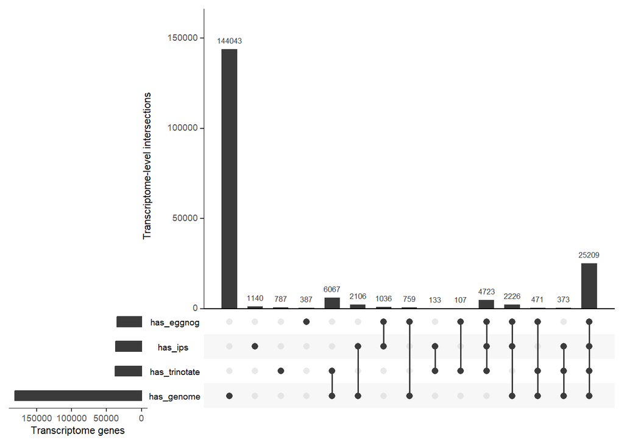

```r
overlap_matrix_transcript <- overlap_data %>%
  mutate(across(-gene_id, ~ as.integer(.))) %>%
  as.data.frame()

rownames(overlap_matrix_transcript) <- overlap_matrix_transcript$gene_id
overlap_matrix_transcript <- overlap_matrix_transcript[,-1]

upset(overlap_matrix_transcript,
      sets = c("has_eggnog","has_ips","has_trinotate","has_genome"),
      mainbar.y.label = "Transcriptome-level intersections",
      sets.x.label = "Transcriptome genes")
```

```r
library(dplyr)
library(tidyr)
library(knitr)

transcript_intersections <- overlap_data %>%
  count(
    has_eggnog,
    has_ips,
    has_trinotate,
    has_genome,
    name = "count"
  ) %>%
  arrange(desc(count))

kable(
  transcript_intersections,
  caption = "Transcriptome-level annotation source intersections underlying the UpSet plot"
)
```

Transcriptome-level annotation source intersections underlying the UpSet plot

| has_eggnog | has_ips | has_trinotate | has_genome | count |
| --- | --- | --- | --- | --- |
| FALSE | FALSE | FALSE | TRUE | 144043 |
| FALSE | FALSE | FALSE | FALSE | 68143 |
| TRUE | TRUE | TRUE | TRUE | 25209 |
| FALSE | FALSE | TRUE | TRUE | 6067 |
| TRUE | TRUE | TRUE | FALSE | 4723 |
| TRUE | TRUE | FALSE | TRUE | 2226 |
| FALSE | TRUE | FALSE | TRUE | 2106 |
| FALSE | TRUE | FALSE | FALSE | 1140 |
| TRUE | TRUE | FALSE | FALSE | 1036 |
| FALSE | FALSE | TRUE | FALSE | 787 |
| TRUE | FALSE | FALSE | TRUE | 759 |
| TRUE | FALSE | TRUE | TRUE | 471 |
| TRUE | FALSE | FALSE | FALSE | 387 |
| FALSE | TRUE | TRUE | TRUE | 373 |
| FALSE | TRUE | TRUE | FALSE | 133 |
| TRUE | FALSE | TRUE | FALSE | 107 |

### Genome Locus Annotation Source Intersections

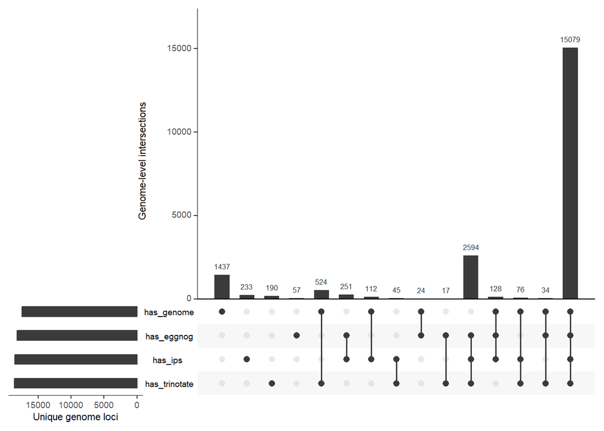

```r
overlap_data_genome <- overlap_data %>%
  filter(!is.na(genome_gene_id)) %>%
  group_by(genome_gene_id) %>%
  summarise(
    has_eggnog    = any(has_eggnog),
    has_ips       = any(has_ips),
    has_trinotate = any(has_trinotate),
    has_genome    = any(has_genome),
    .groups = "drop"
  )

overlap_matrix_genome <- overlap_data_genome %>%
  mutate(across(-genome_gene_id, ~ as.integer(.))) %>%
  as.data.frame()

rownames(overlap_matrix_genome) <- overlap_matrix_genome$genome_gene_id
overlap_matrix_genome <- overlap_matrix_genome[,-1]

upset(overlap_matrix_genome,
      sets = c("has_eggnog","has_ips","has_trinotate","has_genome"),
      mainbar.y.label = "Genome-level intersections",
      sets.x.label = "Unique genome loci")
```

### Summary counts

```r
# Transcript-level totals
source_counts_transcript <- overlap_data %>%
  summarise(
    eggnog_total    = sum(has_eggnog),
    ips_total       = sum(has_ips),
    trinotate_total = sum(has_trinotate)
  )

# Genome-level totals (unique loci)
source_counts_genome <- genome_flags %>%
  summarise(genome_total = sum(has_genome))

# Combined summary
summary_counts <- bind_cols(source_counts_transcript, source_counts_genome)
kable(
  summary_counts,
  caption = "Total number of annotated transcriptome genes per source"
)
```

Total number of annotated transcriptome genes per source

| eggnog_total | ips_total | trinotate_total | genome_total |
| --- | --- | --- | --- |
| 34918 | 36946 | 37870 | 17414 |

### Coverage‑stratified summary table

```r
## Coverage‑stratified summary table
coverage_data <- integrated_table %>%
  mutate(
    coverage_category = case_when(
      is.na(genome_gene_id) ~ "Free Trinity genes (0%)",
      genome_coverage < 40 ~ "Low (<40%)",
      genome_coverage >= 40 & genome_coverage < 70 ~ "Moderate (40–70%)",
      genome_coverage >= 70 ~ "High (≥70%)",
      TRUE ~ "Unclassified"
    ),
    has_eggnog = if_any(starts_with("egg"), ~ !is.na(.) & . != ""),
    has_ips = if_any(starts_with("ips"), ~ !is.na(.) & . != ""),
    has_trinotate = if_any(c("trinotate_BLASTX","trinotate_BLASTP",
                             "trinotate_PFAM","trinotate_GO"),
                           ~ !is.na(.) & . != ""),
    # genome functional annotation flag (GO or UniProt present)
    has_genome = (!is.na(genome_GO) & genome_GO != "") |
                 (!is.na(genome_UniProt) & genome_UniProt != ""),
    # functional annotation flag (any source, including genome functional)
    has_functional = has_trinotate | has_eggnog | has_ips | has_genome
  )

final_summary <- coverage_data %>%
  group_by(coverage_category) %>%
  summarise(
    count            = n(),
    has_genome       = sum(has_genome),
    has_trinotate    = sum(has_trinotate),
    has_eggnog       = sum(has_eggnog),
    has_ips          = sum(has_ips),
    functional_total = sum(has_functional),
    .groups = "drop"
  ) %>%
  mutate(
    coverage_category = factor(
      coverage_category,
      levels = c("High (≥70%)", "Moderate (40–70%)", "Low (<40%)", "Free Trinity genes (0%)")
    )
  ) %>%
  arrange(coverage_category)

kable(
  final_summary,
  caption = "Distribution of genes across coverage categories and annotation sources"
)
```

Distribution of genes across coverage categories and annotation sources

| coverage_category | count | has_genome | has_trinotate | has_eggnog | has_ips | functional_total |
| --- | --- | --- | --- | --- | --- | --- |
| High (≥70%) | 182826 | 174203 | 30824 | 28906 | 30155 | 177192 |
| Moderate (40–70%) | 4844 | 4028 | 3245 | 2819 | 2916 | 4415 |
| Low (<40%) | 6888 | 5184 | 2145 | 1499 | 1672 | 5601 |
| Free Trinity genes (0%) | 63152 | 0 | 1656 | 1694 | 2203 | 2767 |

We stratified transcriptome genes, assembled with Trinity, according to the maximum coverage achieved by any of their transcripts when aligned to genome‑annotated mRNAs. Most genes were highly covered (≥70%), with 182,826 in this class; 177,192 of them (≈97%) carried at least one functional annotation. Genes with moderate coverage (40–70%) numbered 4,844, of which 4,415 (≈91%) were functionally annotated. The low‑coverage class (<40%) contained 6,888 genes, with 5,601 (≈81%) functionally annotated. The smaller proportion of annotated genes in this group suggests that many of the unannotated ones may represent assembly artifacts. Finally, 63,152 free transcriptome genes had no match to genome‑annotated mRNAs, yet 2,767 (≈4%) still carried functional annotation. These unmatched but annotated genes represent novel content uncovered by the transcriptome assembly, expanding the gene catalog beyond what is captured in the current genome annotation.

```r
# Step 1: Define overlap flags (EggNOG, IPS, Trinotate at transcript-level)
overlap_data <- integrated_table %>%
  mutate(
    has_eggnog = if_any(starts_with("egg"), ~ !is.na(.) & . != ""),
    has_ips = if_any(starts_with("ips"), ~ !is.na(.) & . != ""),
    has_trinotate = if_any(c("trinotate_BLASTX","trinotate_BLASTP",
                             "trinotate_PFAM","trinotate_GO"),
                           ~ !is.na(.) & . != ""),
    has_genome = (genome_coverage > 70) &
                 ( (!is.na(genome_GO) & genome_GO != "") |
                   (!is.na(genome_UniProt) & genome_UniProt != "") )
  ) %>%
  select(gene_id, genome_gene_id, has_eggnog, has_ips, has_trinotate, has_genome)

# Step 2: Collapsed genome totals (unique genome_gene_id)
genome_total <- overlap_data %>%
  filter(has_genome) %>%
  distinct(genome_gene_id) %>%
  nrow()

# Step 3: Totals for other sources (still transcript-level)
source_counts <- overlap_data %>%
  summarise(
    eggnog_total    = sum(has_eggnog),
    ips_total       = sum(has_ips),
    trinotate_total = sum(has_trinotate)
  )

# Step 4: Explicit unannotated count
unannotated <- overlap_data %>%
  filter(!has_eggnog & !has_ips & !has_trinotate & !has_genome) %>%
  nrow()

# Step 5: Combine into tidy dataframe
totals <- data.frame(
  Source = c("EggNOG","IPS","Trinotate","Genome","Unannotated"),
  Count  = c(source_counts$eggnog_total,
             source_counts$ips_total,
             source_counts$trinotate_total,
             genome_total,
             unannotated)
)

print(totals)
```

```
##        Source Count
## 1      EggNOG 34918
## 2         IPS 36946
## 3   Trinotate 37870
## 4      Genome 17412
## 5 Unannotated 71725
```

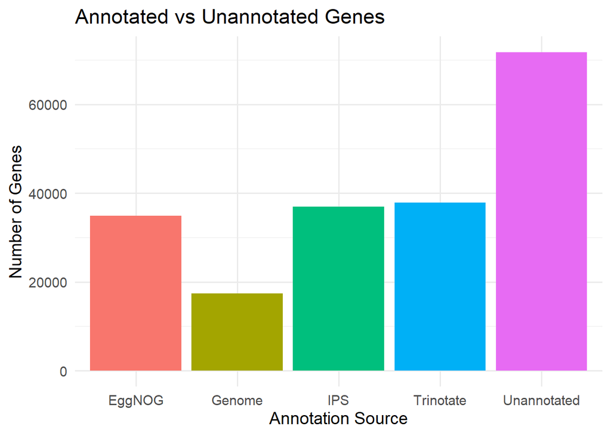

```r
# Step 6: Barplot
ggplot(totals, aes(x=Source, y=Count, fill=Source)) +
  geom_bar(stat="identity") +
  labs(title="Annotated vs Unannotated Genes",
       x="Annotation Source",
       y="Number of Genes") +
  theme_minimal(base_size = 14) +
  theme(legend.position="none")
```

## Tier annotations

### Load all tier gene sets

```r
# Tier 1: shared temperature-responsive genes
tier1_genes <- read_csv(
  "results/functional_enrichment/tier1_shared_temperature_response/tier1_shared_temperature_genes.csv"
)$gene_id

# Tier 2: population divergence
tier2_genes <- read_csv(
  "results/functional_enrichment/tier2_pop_divergence/tier2_pop_divergence_genes.csv"
)$gene_id

# Tier 2b: locally adapted thermal genes
tier2b_genes <- read_csv(
  "results/functional_enrichment/tier2_pop_divergence/tier2b_local_adaptation/tier2b_local_adaptation_candidates.csv"
)$gene_id

# Tier 3: hybrid inheritance categories
tier3_mis_genes <- read_csv(
  "results/functional_enrichment/tier3_hybrid_inheritance/tier3_misexpressed_genes.csv"
)$gene_id

tier3_parent_S_genes <- read_csv(
  "results/functional_enrichment/tier3_hybrid_inheritance/tier3_parent_like_S_genes.csv"
)$gene_id

tier3_parent_W_genes <- read_csv(
  "results/functional_enrichment/tier3_hybrid_inheritance/tier3_parent_like_W_genes.csv"
)$gene_id

# Intersections
tier1_tier3_mis <- read_csv("results/functional_enrichment/tier_intersections/tier1_tier3_misexpressed.csv")$gene_id
tier1_tier3_parent_S <- read_csv("results/functional_enrichment/tier_intersections/tier1_tier3_parent_like_S.csv")$gene_id
tier1_tier3_parent_W <- read_csv("results/functional_enrichment/tier_intersections/tier1_tier3_parent_like_W.csv")$gene_id

tier2b_tier3_mis <- read_csv("results/functional_enrichment/tier_intersections/tier2b_tier3_misexpressed.csv")$gene_id
tier2b_tier3_parent_S <- read_csv("results/functional_enrichment/tier_intersections/tier2b_tier3_parent_like_S.csv")$gene_id
tier2b_tier3_parent_W <- read_csv("results/functional_enrichment/tier_intersections/tier2b_tier3_parent_like_W.csv")$gene_id
```

```r
# Count number of genes per tier and intersection
tier_sizes <- tibble(
  tier = c("Tier1","Tier2","Tier2b",
           "Tier3_mis","Tier3_parent_S","Tier3_parent_W",
           "Tier1∩Tier3_mis","Tier1∩Tier3_parent_S","Tier1∩Tier3_parent_W",
           "Tier2b∩Tier3_mis","Tier2b∩Tier3_parent_S","Tier2b∩Tier3_parent_W"),
  n_genes = c(length(tier1_genes),
              length(tier2_genes),
              length(tier2b_genes),
              length(tier3_mis_genes),
              length(tier3_parent_S_genes),
              length(tier3_parent_W_genes),
              length(tier1_tier3_mis),
              length(tier1_tier3_parent_S),
              length(tier1_tier3_parent_W),
              length(tier2b_tier3_mis),
              length(tier2b_tier3_parent_S),
              length(tier2b_tier3_parent_W))
)

knitr::kable(
  tier_sizes,
  caption = "Number of genes per tier and intersection",
  align = "c"
)
```

Number of genes per tier and intersection

| tier | n_genes |
| --- | --- |
| Tier1 | 593 |
| Tier2 | 1498 |
| Tier2b | 45 |
| Tier3_mis | 727 |
| Tier3_parent_S | 936 |
| Tier3_parent_W | 3067 |
| Tier1∩Tier3_mis | 23 |
| Tier1∩Tier3_parent_S | 37 |
| Tier1∩Tier3_parent_W | 146 |
| Tier2b∩Tier3_mis | 1 |
| Tier2b∩Tier3_parent_S | 3 |
| Tier2b∩Tier3_parent_W | 33 |

```r
# Helper function: subset classified_genes by tier/intersection membership
make_tier_table <- function(gene_ids, tier_name, classified_table) {
  classified_table %>%
    filter(gene_id %in% gene_ids) %>%
    mutate(tier = tier_name) %>%
    relocate(tier, .before = gene_id)
}

# --- Build tables for main tiers ---
tier1_table <- make_tier_table(tier1_genes, "Tier1", classified_genes)
tier2_table <- make_tier_table(tier2_genes, "Tier2", classified_genes)
tier2b_table <- make_tier_table(tier2b_genes, "Tier2b", classified_genes)
tier3_mis_table <- make_tier_table(tier3_mis_genes, "Tier3_mis", classified_genes)
tier3_parentS_table <- make_tier_table(tier3_parent_S_genes, "Tier3_parent_S", classified_genes)
tier3_parentW_table <- make_tier_table(tier3_parent_W_genes, "Tier3_parent_W", classified_genes)

# --- Build tables for intersections ---
tier1_tier3_mis_table <- make_tier_table(intersect(tier1_genes, tier3_mis_genes),
                                         "Tier1∩Tier3_mis", classified_genes)
tier1_tier3_parentS_table <- make_tier_table(intersect(tier1_genes, tier3_parent_S_genes),
                                             "Tier1∩Tier3_parent_S", classified_genes)
tier1_tier3_parentW_table <- make_tier_table(intersect(tier1_genes, tier3_parent_W_genes),
                                             "Tier1∩Tier3_parent_W", classified_genes)

tier2b_tier3_mis_table <- make_tier_table(intersect(tier2b_genes, tier3_mis_genes),
                                          "Tier2b∩Tier3_mis", classified_genes)
tier2b_tier3_parentS_table <- make_tier_table(intersect(tier2b_genes, tier3_parent_S_genes),
                                              "Tier2b∩Tier3_parent_S", classified_genes)
tier2b_tier3_parentW_table <- make_tier_table(intersect(tier2b_genes, tier3_parent_W_genes),
                                              "Tier2b∩Tier3_parent_W", classified_genes)

# --- Combine everything into one master table ---
all_tiers_and_intersections <- bind_rows(
  tier1_table, tier2_table, tier2b_table,
  tier3_mis_table, tier3_parentS_table, tier3_parentW_table,
  tier1_tier3_mis_table, tier1_tier3_parentS_table, tier1_tier3_parentW_table,
  tier2b_tier3_mis_table, tier2b_tier3_parentS_table, tier2b_tier3_parentW_table
)

# Preview of master table
shorten <- function(x, n = 50) {
  ifelse(nchar(x) > n, paste0(substr(x, 1, n), "..."), x)
}

preview_table <- all_tiers_and_intersections %>%
  mutate(across(where(is.character), ~ shorten(.)))

datatable(
  head(preview_table, 100),
  options = list(pageLength = 20, scrollX = TRUE),
  caption = "Preview of classified genes (truncated text fields)"
)
```

|  | tier | gene_id | egg_ortholog | egg_desc | egg_COG | egg_KO | egg_KEGGmap | egg_PFAM | egg_GO | ips_IPR | ips_PFAM | ips_GO | trinotate_BLASTX | trinotate_BLASTP | trinotate_PFAM | trinotate_GO | trinotate_SignalP | trinotate_TMHMM | genome_best_transcript | genome_gene_id | genome_coverage | genome_GO | genome_UniProt | genome_Dbxref | has_eggnog | has_ips_go | has_trinotate_go | blastx_strong | blastp_strong | … |
| --- | --- | --- | --- | --- | --- | --- | --- | --- | --- | --- | --- | --- | --- | --- | --- | --- | --- | --- | --- | --- | --- | --- | --- | --- | --- | --- | --- | --- | --- | --- |
| 1 | Tier1 | TRINITY_GG_11_c9_g3 |  |  |  |  |  |  |  |  | PS51257;Coil;mobidb-lite |  |  |  |  |  | NO | NO | TRINITY_GG_11_c9_g3_i1 | FUNCG00000014264 | 8.83615 |  |  |  | False | False | False | False | False | … |
| 2 | Tier1 | TRINITY_GG_11_c65_g2 | 215358.XP_010732763.1 | Plac8 onzin related protein | S |  |  | PLAC8 | - | IPR006461 | TIGR01571;PTHR15907;PF04749 |  | sp\|Q6DK99\|CNFNB_XENLA^sp\|Q6DK99\|CNFNB_XENLA^Q:385-... | sp\|Q6DK99\|CNFNB_XENLA^sp\|Q6DK99\|CNFNB_XENLA^Q:3-11... | PF04749.23^PLAC8^NULL^22-112^E:5.2e-17;PF04749.23^... |  | NO | NO | TRINITY_GG_11_c65_g2_i1 | FUNCG00000014248 | 55.5324 |  |  | InterPro:IPR006461,NCBIfam:TIGR01571,PANTHER:PTHR1... | True | False | False | True | True | … |
| 3 | Tier1 | TRINITY_GG_13_c7_g1 | 106582.XP_004561826.1;144197.XP_008295387.1;215358... | DEAD (Asp-Glu-Ala-Asp) box polypeptide 46 | A | ko:K12811 | ko03040;map03040 | Helicase_C;DEAD;DEAD;Helicase_C | GO:0000375;GO:0000377;GO:0000398;GO:0001650;GO:000... | IPR027417;IPR001650;IPR014001;IPR011545;IPR014014;... | cd18787;cd22473;G3DSA:3.40.50.300:FF:000584;G3DSA:... | GO:0003676;GO:0005524;GO:0003724;GO:0003723;GO:000... | sp\|Q4TVV3\|DDX46_DANRE^sp\|Q4TVV3\|DDX46_DANRE^Q:3629... | sp\|Q4TVV3\|DDX46_DANRE^sp\|Q4TVV3\|DDX46_DANRE^Q:1-51... | PF00271.38^Helicase_C^NULL^72-181^E:7.1e-29`PF2346... | GO:0003676^molecular_function^nucleic acid binding... | NO | NO | TRINITY_GG_13_c7_g1_i2 | FUNCG00000013552 | 96.7867 | GO:0003676,GO:0005524,GO:0003724 | Q4TVV3 | CDD:cd18787,CDD:cd17953,CDD:cd22473,Coils:Coil,Fun... | True | True | True | True | True | … |
| 4 | Tier1 | TRINITY_GG_14_c64_g1 | 8083.ENSXMAP00000013118;144197.XP_008294805.1;3035... | Pleckstrin homology-like domain family B member 2;... | T |  |  | PH | GO:0000226;GO:0001952;GO:0001953;GO:0005622;GO:000... | IPR037810;IPR011993;IPR001849 | Coil;mobidb-lite;PTHR12156;cd14673;G3DSA:2.30.29.3... |  | sp\|Q86SQ0\|PHLB2_HUMAN^sp\|Q86SQ0\|PHLB2_HUMAN^Q:7239... | sp\|Q86SQ0\|PHLB2_HUMAN^sp\|Q86SQ0\|PHLB2_HUMAN^Q:8-23... | PF00169.36^PH^NULL^128-222^E:1.5e-17;PF00169.36^PH... |  | NO | YES | TRINITY_GG_14_c64_g1_i13 | FUNCG00000014024 | 100 |  | Q86SQ0 | CDD:cd14673,Coils:Coil,FunFam:G3DSA:2.30.29.30:FF:... | True | False | False | True | True | … |
| 5 | Tier1 | TRINITY_GG_14_c122_g1 | 215358.XP_010748510.1;144197.XP_008283308.1 | ADAM metallopeptidase with thrombospondin type 1 m... | O | ko:K08629 |  | ADAM_spacer1;TSP_1;ADAM_spacer1;Pep_M12B_propep;Re... | GO:0003824;GO:0004175;GO:0005488;GO:0005539;GO:000... | IPR036383;IPR013273;IPR000884;IPR010294;IPR041645;... | G3DSA:2.20.100.10:FF:000005;G3DSA:2.20.100.10:FF:0... | GO:0030198;GO:0008237;GO:0008237;GO:0008270;GO:006... | sp\|P59384\|ATS15_MOUSE^sp\|P59384\|ATS15_MOUSE^Q:934-... | sp\|P59384\|ATS15_MOUSE^sp\|P59384\|ATS15_MOUSE^Q:5-49... | PF17771.7^ADAMTS_CR_2^NULL^3-44^E:1.5e-08`PF00090.... | GO:0004222^molecular_function^metalloendopeptidase... | YES | NO | TRINITY_GG_14_c122_g1_i15 | FUNCG00000014091 | 80.0467 | GO:0008237,GO:0008270,GO:0062023,GO:0004222,GO:000... | P59384 | CDD:cd04273,FunFam:G3DSA:2.20.100.10:FF:000005,Fun... | True | True | True | True | True | … |
| 6 | Tier1 | TRINITY_GG_14_c216_g1 | 106582.XP_004564137.1;8153.XP_005922282.1 | Low affinity cationic amino acid transporter 2-lik... | E | ko:K13863;ko:K13864;ko:K13865 | ko05206;map05206 | AA_permease_2;AA_permease_2;AA_permease_C | GO:0003333;GO:0005215;GO:0005342;GO:0005623;GO:000... | IPR002293;IPR029485 | mobidb-lite;G3DSA:1.20.1740.10;PTHR43243;PF13520;G... | GO:0016020;GO:0022857;GO:0055085 | sp\|A8I499\|CTR2_PIG^sp\|A8I499\|CTR2_PIG^Q:296-1063,H... | sp\|A8I499\|CTR2_PIG^sp\|A8I499\|CTR2_PIG^Q:38-293,H:2... | PF00324.28^AA_permease^NULL^34-194^E:6.3e-20`PF135... | GO:0055085^biological_process^transmembrane transp... | NO | YES | TRINITY_GG_14_c216_g1_i4 | FUNCG00000014045 | 100 | GO:0006865,GO:0016020,GO:0022857,GO:0055085 | Q6DCE8 | FunFam:G3DSA:1.20.1740.10:FF:000009,FunFam:G3DSA:1... | True | True | True | True | True | … |
| 7 | Tier1 | TRINITY_GG_15_c0_g2 | 215358.XP_010750361.1 | Fasciculation and elongation protein | U |  |  | FEZ | GO:0000902;GO:0000904;GO:0005080;GO:0005488;GO:000... | IPR011680 | Coil;mobidb-lite;PTHR12394;PF07763 |  | sp\|Q8K0X8\|FEZ1_MOUSE^sp\|Q8K0X8\|FEZ1_MOUSE^Q:2301-3... | sp\|P97577\|FEZ1_RAT^sp\|P97577\|FEZ1_RAT^Q:4-253,H:15... | PF07763.19^FEZ^NULL^1-151^E:6.9e-49;PF07763.19^FEZ... |  | NO | NO | TRINITY_GG_15_c0_g2_i17 | FUNCG00000013454 | 100 |  | Q8K0X8 | Coils:Coil,InterPro:IPR011680,MobiDBLite:mobidb-li... | True | False | False | True | True | … |
| 8 | Tier1 | TRINITY_GG_19_c2_g1 | 8090.ENSORLP00000004224 | High mobility group protein | K | ko:K10802;ko:K11295 | ko03410;ko04140;ko04217;map03410;map04140;map04217 | HMG_box_2;HMG_box;HMG_box_2 | GO:0000003;GO:0000122;GO:0000217;GO:0000228;GO:000... | IPR036910;IPR009071;IPR017967 | cd21978;cd21979;Coil;G3DSA:1.10.30.10:FF:000006;G3... | GO:0003677;GO:0005634 | sp\|P07746\|HMGT_ONCMY^sp\|P07746\|HMGT_ONCMY^Q:2482-3... | sp\|P07746\|HMGT_ONCMY^sp\|P07746\|HMGT_ONCMY^Q:1-156,... | PF09011.17^HMG_box_2^NULL^5-77^E:4.4e-25`PF00505.2... |  | NO | NO | TRINITY_GG_19_c2_g1_i25 | FUNCG00000013881 | 40.3509 | GO:0003677,GO:0005634 | Q9YH06 | CDD:cd21978,CDD:cd21979,FunFam:G3DSA:1.10.30.10:FF... | True | True | False | True | True | … |
| 9 | Tier1 | TRINITY_GG_19_c3_g1 | 215358.XP_010750793.1;144197.XP_008295901.1;215358... | Periostin; osteoblast specific factor a;Transient ... | MW;PT | ko:K19519;ko:K04964;ko:K04967;ko:K04968;ko:K13803;... | ko04360;ko04724;ko04726;ko04745;ko04972;map04360;m... | Fasciclin;Ion_trans;TRP_2;Ank_2;Ion_trans;TRP_2 | GO:0000902;GO:0001501;GO:0001817;GO:0001819;GO:000... | IPR036770;IPR002153;IPR005821;IPR013555;IPR002110;... | Coil;G3DSA:1.10.287.70:FF:000266;G3DSA:1.25.40.20:... | GO:0005262;GO:0016020;GO:0070588;GO:0005216;GO:000... | sp\|Q9UBN4\|TRPC4_HUMAN^sp\|Q9UBN4\|TRPC4_HUMAN^Q:680-... | sp\|Q62009\|POSTN_MOUSE^sp\|Q62009\|POSTN_MOUSE^Q:3-33... | PF02469.28^Fasciclin^NULL^3-52^E:6.9e-10`PF02469.2... | GO:0005515^molecular_function^protein binding`GO:0... | YES | YES | TRINITY_GG_19_c3_g1_i128 | FUNCG00000013851 | 100 | GO:0005515 | Q62009 | FunFam:G3DSA:2.30.180.10:FF:000002,FunFam:G3DSA:2.... | True | True | True | True | True | … |
| 10 | Tier1 | TRINITY_GG_19_c12_g8 |  |  |  |  |  |  |  |  |  |  |  |  |  |  | NO | NO |  |  |  |  |  |  | False | False | False | False | False | … |

[output cut: 90 more lines]

### Tier class summaries

```r
# Helper: summarise annotation classes as proportions
summarise_tier <- function(gene_ids, tier_name, classified_table) {
  classified_table %>%
    filter(gene_id %in% gene_ids) %>%
    count(annotation_class) %>%
    mutate(percent = round(n / sum(n) * 100, 1),
           tier = tier_name)
}

# Collect summaries for all tiers and intersections
all_tiers_summary <- bind_rows(
  summarise_tier(tier1_genes, "Tier1", classified_genes),
  summarise_tier(tier2_genes, "Tier2", classified_genes),
  summarise_tier(tier2b_genes, "Tier2b", classified_genes),
  summarise_tier(tier3_mis_genes, "Tier3_mis", classified_genes),
  summarise_tier(tier3_parent_S_genes, "Tier3_parent_S", classified_genes),
  summarise_tier(tier3_parent_W_genes, "Tier3_parent_W", classified_genes),
  summarise_tier(tier1_tier3_mis, "Tier1∩Tier3_mis", classified_genes),
  summarise_tier(tier1_tier3_parent_S, "Tier1∩Tier3_parent_S", classified_genes),
  summarise_tier(tier1_tier3_parent_W, "Tier1∩Tier3_parent_W", classified_genes),
  summarise_tier(tier2b_tier3_mis, "Tier2b∩Tier3_mis", classified_genes),
  summarise_tier(tier2b_tier3_parent_S, "Tier2b∩Tier3_parent_S", classified_genes),
  summarise_tier(tier2b_tier3_parent_W, "Tier2b∩Tier3_parent_W", classified_genes)
)

all_tiers_summary
```

```
## # A tibble: 46 × 4
##    annotation_class        n percent tier
##    <chr>               <int>   <dbl> <chr>
##  1 Mapped only             7     1.2 Tier1
##  2 Partially annotated    39     6.6 Tier1
##  3 Unannotated            48     8.1 Tier1
##  4 Weakly annotated       15     2.5 Tier1
##  5 Well-annotated        484    81.6 Tier1
##  6 Mapped only            11     0.7 Tier2
##  7 Partially annotated   113     7.5 Tier2
##  8 Unannotated           231    15.4 Tier2
##  9 Weakly annotated       37     2.5 Tier2
## 10 Well-annotated       1106    73.8 Tier2
## # ℹ 36 more rows
```

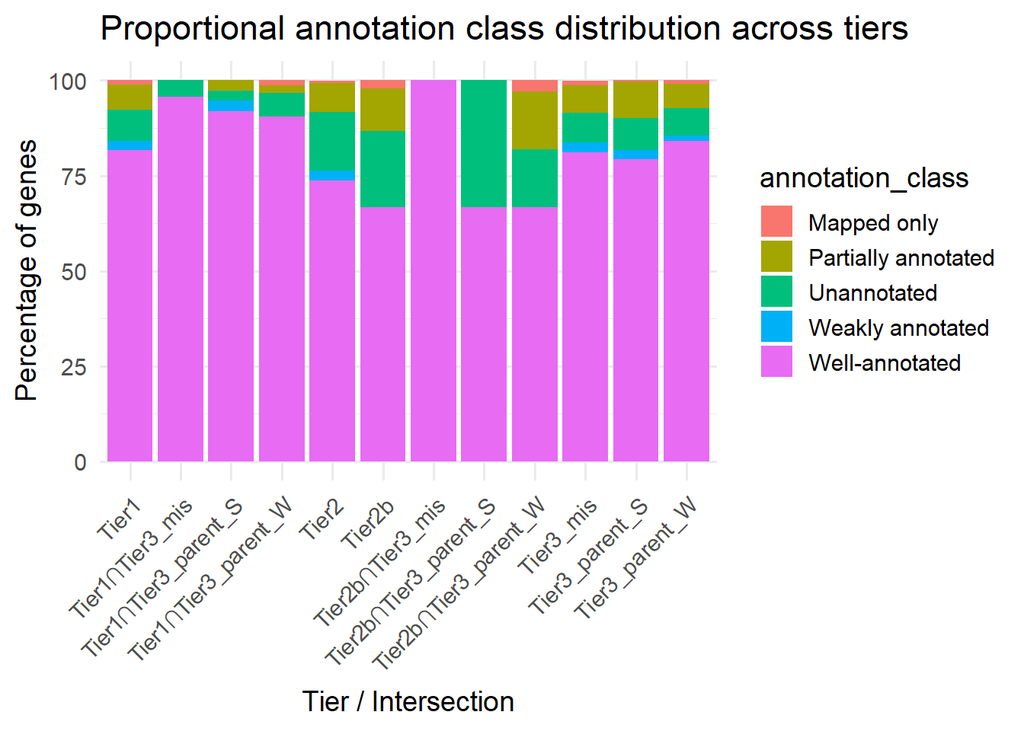

```r
# Plot proportions instead of raw counts
ggplot(all_tiers_summary, aes(x=tier, y=percent, fill=annotation_class)) +
  geom_bar(stat="identity", position="stack") +
  labs(title="Proportional annotation class distribution across tiers",
       x="Tier / Intersection",
       y="Percentage of genes") +
  theme_minimal(base_size = 14) +
  theme(axis.text.x = element_text(angle=45, hjust=1))
```

Intersections between tiers largely reflected the annotation properties of the parent sets. Overlaps between Tier1 and Tier3 categories were predominantly well‑annotated (>90%), as expected given that both sets represent conserved functions. In contrast, overlaps involving Tier2b showed more variability. The Tier2b∩Tier3_mis intersection yielded a single, well‑annotated gene: a CD81‑like tetraspanin.

The Tier2b∩Tier3_parent_S intersection contained a single unannotated gene. Although its function remains unresolved, its retention after ORF quality filtering suggests coding potential.

### Tier‑level Ortholog Annotation Summary

```r
tier_summary <- all_tiers_and_intersections %>%
  mutate(zebrafish_hit = grepl("7955|ENSDARG|DANRE",
                               paste(egg_ortholog, trinotate_BLASTX, trinotate_BLASTP, genome_UniProt),
                               ignore.case = TRUE),
         human_hit     = grepl("9606|ENSP|ENSG|HUMAN",
                               paste(egg_ortholog, trinotate_BLASTX, trinotate_BLASTP, genome_UniProt),
                               ignore.case = TRUE),
         any_hit       = zebrafish_hit | human_hit) %>%
  group_by(tier) %>%
  summarise(
    total_genes     = n(),
    zebrafish_hits  = sum(zebrafish_hit, na.rm = TRUE),
    human_hits      = sum(human_hit, na.rm = TRUE),
    annotated       = sum(any_hit, na.rm = TRUE),
    unannotated     = total_genes - annotated
  )


knitr::kable(
  tier_summary,
  caption = "Counts of zebrafish and human ortholog hits per tier",
  align = "c"
)
```

Counts of zebrafish and human ortholog hits per tier

| tier | total_genes | zebrafish_hits | human_hits | annotated | unannotated |
| --- | --- | --- | --- | --- | --- |
| Tier1 | 593 | 120 | 463 | 470 | 123 |
| Tier1∩Tier3_mis | 23 | 4 | 20 | 20 | 3 |
| Tier1∩Tier3_parent_S | 37 | 8 | 32 | 34 | 3 |
| Tier1∩Tier3_parent_W | 146 | 35 | 128 | 130 | 16 |
| Tier2 | 1498 | 271 | 1043 | 1065 | 433 |
| Tier2b | 45 | 5 | 30 | 32 | 13 |
| Tier2b∩Tier3_mis | 1 | 0 | 1 | 1 | 0 |
| Tier2b∩Tier3_parent_S | 3 | 1 | 2 | 2 | 1 |
| Tier2b∩Tier3_parent_W | 33 | 2 | 22 | 23 | 10 |
| Tier3_mis | 727 | 156 | 552 | 570 | 157 |
| Tier3_parent_S | 936 | 190 | 692 | 713 | 223 |
| Tier3_parent_W | 3067 | 730 | 2457 | 2506 | 561 |

## Tier 2b example: partial genome reconstruction of a cyclin‑dependent kinase regulator (CKS1)

```r
tier2b_table %>%
  filter(gene_id == "TRINITY_GG_416_c2774_g1") %>%
  datatable(
    rownames = FALSE,
    options = list(
      dom = "t",
      pageLength = 1,
      ordering = FALSE
    ),
    caption = htmltools::tags$caption(
      style = "caption-side: top; font-weight: bold;",
      "Tier 2b example gene (moderate transcriptome–genome coverage)"
    )
  )
```

| tier | gene_id | egg_ortholog | egg_desc | egg_COG | egg_KO | egg_KEGGmap | egg_PFAM | egg_GO | ips_IPR | ips_PFAM | ips_GO | trinotate_BLASTX | trinotate_BLASTP | trinotate_PFAM | trinotate_GO | trinotate_SignalP | trinotate_TMHMM | genome_best_transcript | genome_gene_id | genome_coverage | genome_GO | genome_UniProt | genome_Dbxref | has_eggnog | has_ips_go | has_trinotate_go | blastx_strong | blastp_strong | has_blast | … |
| --- | --- | --- | --- | --- | --- | --- | --- | --- | --- | --- | --- | --- | --- | --- | --- | --- | --- | --- | --- | --- | --- | --- | --- | --- | --- | --- | --- | --- | --- | --- |
| Tier2b | TRINITY_GG_416_c2774_g1 |  |  |  |  |  |  |  |  |  |  | sp\|P61025\|CKS1_MOUSE^sp\|P61025\|CKS1_MOUSE^Q:2-160,H:21-73^94.34%ID^E:1.03e-26^.^.;sp\|P61025\|CKS1_MOUSE^sp\|P61025\|CKS1_MOUSE^Q:294-512,H:1-73^93.151%ID^E:7.35e-31^.^.;sp\|P61025\|CKS1_MOUSE^sp\… |  |  |  | NO | NO | TRINITY_GG_416_c2774_g1_i14 | FUNCG00000020675 | 65.0459 | GO:0016538 | Q0P5A5 | FunFam:G3DSA:3.30.170.10:FF:000001,Gene3D:G3DSA:3.30.170.10,InterPro:IPR000789,InterPro:IPR036858,PANTHER:PTHR23415,PRINTS:PR00296,Pfam:PF01111,ProSitePatterns:PS00944,ProSitePatterns:PS00945,SMART:SM… | False | False | False | True | False | True | … |

TRINITY_GG_416_c2774_g1 represents a Trinity‑assembled gene with strong homology to cyclin‑dependent kinase regulatory subunit 1 (CKS1). BLAST searches against UniProt identify multiple high‑confidence alignments to CKS1_MOUSE (P61025), each exceeding 90% sequence identity with highly significant E‑values, supporting functional conservation. Among its isoforms, TRINITY_GG_416_c2774_g1_i14 achieved a maximum alignment of ~65% coverage to the genome‑annotated mRNA FUNCG00000020675. This indicates that the genome gene/mRNA model is only partially reconstructed relative to the Trinity assembly. Importantly, the genome‑based annotation was informative: InterPro, Pfam, SMART, and ProSite domain assignments (e.g. IPR000789, PF01111, SM01084, PS00944/45) provided a GO term consistent with cyclin‑dependent protein kinase regulator activity (GO:0016538). In this case, the Trinity assembly provides a more complete sequence that reinforces and complements the functional assignment derived from the genome annotation. CKS1 proteins are canonical regulators of cyclin‑dependent kinases, controlling cell cycle progression and transcriptional programs. While they are not classical “temperature response” genes like heat shock proteins, their regulatory role means they can indirectly influence how cells cope with stress. Temperature shifts often impose cellular stress that requires adjustments in proliferation, DNA repair, and transcriptional regulation. In this study, TRINITY_GG_416_c2774_g1 was differentially expressed between corkwing wrasse populations exposed to thermal treatments, suggesting that modulation of CDK activity may contribute to population‑specific responses and local adaptation to contrasting temperature regimes. A change in CKS1 expression could therefore reflect altered cell cycle control or stress adaptation pathways under different thermal environments.